# Cosy analysis

Louise Bernard

2024-01-12

## Introduction

This document presents the results of the impact of the adoption of cosy tariff on smart meter electricity consumption at the household level.

To do: - Add weather [done - but using reanalysis data, the MET data from databricks only starts in 2022] - Implement Callaway and sant’anna DiD [done but more work needed on the panel balance] - Decide of a threshold for the event study (how many weeks before / after adoption we want to capture, do we want to put all weeks before in a large category or exclude them) - Can we find out when they install their HP

## Descriptive statistics on cosy adoption

The Cosy tariff has 4 different periods:

[figure not shown]

Cosy double dip

This bar chart shows average consumption pre and post cosy for each period of the day:

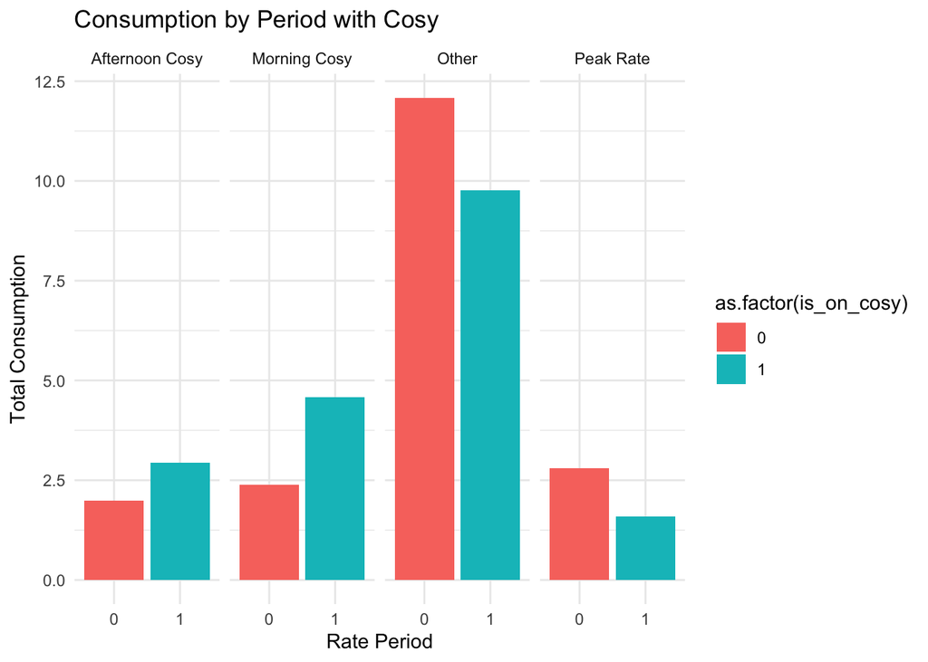

```r
# Prepare data for bar chart
if (!file.exists("data/scratch/cosy_data.RDS")) {
  cosy_data <- aggregated_data %>%
    group_by(is_on_cosy, rate_period) %>%
    summarise(total_consumption = mean(total_consumption))
  saveRDS(cosy_data, "data/scratch/cosy_data.RDS")
} else {
  cosy_data <- readRDS("data/scratch/cosy_data.RDS")
}
# Line Plot
ggplot(cosy_data, aes(x = as.factor(is_on_cosy), y = total_consumption, fill = as.factor(is_on_cosy))) +
  geom_bar(stat = "identity") +
  labs(title = "Consumption by Period with Cosy", x = "Rate Period", y = "Total Consumption") +
  theme_minimal() +
  facet_grid(~rate_period)
```

## Difference in differences

We run the following model by period and on total daily consumption for all customers that have adopted Cosy in the past year:

$$Consumption_{it} = \alpha OnCosy_{it} +
\delta_t + \gamma_i + GSP \times \delta_t+ \epsilon_{it}$$
with: - $Consumption_{it}$ - electricty consumption in kWh (column 1) and log (column 2) for customer $i$ on day $t$ - $OnCosy_{it}$ a dummy variable equals 1 if the customer has switched to Cosy, 0 otherwise. To be noted: right now, adoption is permanent, I am not switching back to 0 for people that switched to another tariff - $\delta_t$, $\gamma_i$, $ GSP _t$ are day $t$, customer $i$, and GSP regions times day fixed effects The standard errors are clustered at the customer (MPAN) level.

### Consumption by period

```r
aggregated_data <- aggregated_data %>%
  left_join(weather, by=c("date"="next_date_day", "tariff_gsp_group_id" = "gsp_group_id")) %>%
    mutate(month = floor_date(date, "month")) %>%
  filter(month %in% heating_months$month)


if (!file.exists("data/scratch/did_table.RDS")) {

  m1 <- feols(total_consumption ~ as.factor(is_on_cosy) | date + mpan + date^tariff_gsp_group_id,
              data = aggregated_data,
              cluster = ~mpan,
              split = ~ rate_period)

  m2 <- feols(log(total_consumption) ~ as.factor(is_on_cosy) | date + mpan + date^tariff_gsp_group_id,
              data = aggregated_data,
              cluster = ~mpan,
              split = ~ rate_period)
  did_table <- etable(m1, m2)
  saveRDS(did_table, "data/scratch/did_table.RDS")
} else {
  did_table <- readRDS("data/scratch/did_table.RDS")
}

did_table
```

```
##                                       m1.1              m1.2               m1.3
## Sample (rate_period)        Afternoon Cosy      Morning Cosy              Other
## Dependent Var.:          total_consumption total_consumption  total_consumption
##
## as.factor(is_on_cosy)1   1.738*** (0.1054) 3.041*** (0.1527) -2.639*** (0.3250)
## Fixed-Effects:           ----------------- ----------------- ------------------
## date                                   Yes               Yes                Yes
## mpan                                   Yes               Yes                Yes
## date-tariff_gsp_group_id               Yes               Yes                Yes
## ________________________ _________________ _________________ __________________
## S.E.: Clustered                   by: mpan          by: mpan           by: mpan
## Observations                       742,490           742,336            744,340
## R2                                 0.47498           0.56487            0.66376
## Within R2                          0.02417           0.05631            0.00540
##
##                                        m1.4                   m2.1
## Sample (rate_period)              Peak Rate         Afternoon Cosy
## Dependent Var.:           total_consumption log(total_consumption)
##
## as.factor(is_on_cosy)1   -1.445*** (0.0823)     0.6636*** (0.0456)
## Fixed-Effects:           ------------------ ----------------------
## date                                    Yes                    Yes
## mpan                                    Yes                    Yes
## date-tariff_gsp_group_id                Yes                    Yes
## ________________________ __________________ ______________________
## S.E.: Clustered                    by: mpan               by: mpan
## Observations                        742,500                719,587
## R2                                  0.51804                0.52269
## Within R2                           0.01648                0.01128
##
##                                            m2.2                   m2.3
## Sample (rate_period)               Morning Cosy                  Other
## Dependent Var.:          log(total_consumption) log(total_consumption)
##
## as.factor(is_on_cosy)1       0.8158*** (0.0430)    -0.1451*** (0.0356)
## Fixed-Effects:           ---------------------- ----------------------
## date                                        Yes                    Yes
## mpan                                        Yes                    Yes
## date-tariff_gsp_group_id                    Yes                    Yes
## ________________________ ______________________ ______________________
## S.E.: Clustered                        by: mpan               by: mpan
## Observations                            734,304                739,946
## R2                                      0.57843                0.60255
## Within R2                               0.02776                0.00154
##
##                                            m2.4
## Sample (rate_period)                  Peak Rate
## Dependent Var.:          log(total_consumption)
##
## as.factor(is_on_cosy)1      -0.6017*** (0.0530)
## Fixed-Effects:           ----------------------
## date                                        Yes
## mpan                                        Yes
## date-tariff_gsp_group_id                    Yes
## ________________________ ______________________
## S.E.: Clustered                        by: mpan
## Observations                            733,292
## R2                                      0.56217
## Within R2                               0.01149
## ---
## Signif. codes: 0 '***' 0.001 '**' 0.01 '*' 0.05 '.' 0.1 ' ' 1
```

```r
rm(did_table)
```

### Total electricity consumption

We repeat the same analysis on total daily consumption (all periods together):

```r
# aggregate all periods together to get daily consumption
if (!file.exists("data/scratch/did_daily_table.RDS")) {
  tot <- aggregated_data %>% group_by(mpan, date, is_on_cosy, tariff_gsp_group_id) %>%
    summarise(total_consumption=sum(total_consumption))

  m1 <- feols(total_consumption ~ as.factor(is_on_cosy) | date + mpan + date^tariff_gsp_group_id,
              data = tot,
              cluster = ~mpan)

  m2 <- feols(log(total_consumption) ~ as.factor(is_on_cosy) | date + mpan + date^tariff_gsp_group_id,
              data = tot,
              cluster = ~mpan)
  did_daily_table <- etable(m1, m2)
  saveRDS(did_daily_table, "data/scratch/did_daily_table.RDS")

} else {
  did_daily_table <- readRDS("data/scratch/did_daily_table.RDS")
}
did_daily_table
```

```
##                                         m1                     m2
## Dependent Var.:          total_consumption log(total_consumption)
##
## as.factor(is_on_cosy)1    0.7577. (0.3947)     0.1734*** (0.0268)
## Fixed-Effects:           ----------------- ----------------------
## date                                   Yes                    Yes
## mpan                                   Yes                    Yes
## date-tariff_gsp_group_id               Yes                    Yes
## ________________________ _________________ ______________________
## S.E.: Clustered                   by: mpan               by: mpan
## Observations                       744,340                740,085
## R2                                 0.68647                0.62159
## Within R2                          0.00020                0.00250
## ---
## Signif. codes: 0 '***' 0.001 '**' 0.01 '*' 0.05 '.' 0.1 ' ' 1
```

```r
rm(did_daily_table)
```

## Event study

$$Consumption_{it} = \sum^W _{w={-140, -9,
..., 1, ..,28}} \alpha_w WeeksSinceCosy^w_{it} + X\beta + \delta_t
+ \gamma_i + \epsilon_{it}$$
where: - $WeeksSinceCosy^w_{it}$ is a categorical variable equals to the number of weeks before and after the adoption of Cosy. We use the week prior adoption as omitted category.

## Callaway Sant’Anna DiD

```
## [1] "Aggregate effect for Afternoon Cosy"
##
## Call:
## aggte(MP = est_cs, type = "simple", na.rm = TRUE, clustervars = "id")
##
## Reference: Callaway, Brantly and Pedro H.C. Sant'Anna.  "Difference-in-Differences with Multiple Time Periods." Journal of Econometrics, Vol. 225, No. 2, pp. 200-230, 2021. <https://doi.org/10.1016/j.jeconom.2020.12.001>, <https://arxiv.org/abs/1803.09015>
##
##
##      ATT    Std. Error     [ 95%  Conf. Int.]
##  10.0111         1.564     6.9457     13.0765 *
##
##
## ---
## Signif. codes: `*' confidence band does not cover 0
##
## Control Group:  Not Yet Treated,  Anticipation Periods:  0
## Estimation Method:  Doubly Robust
## NULL
```

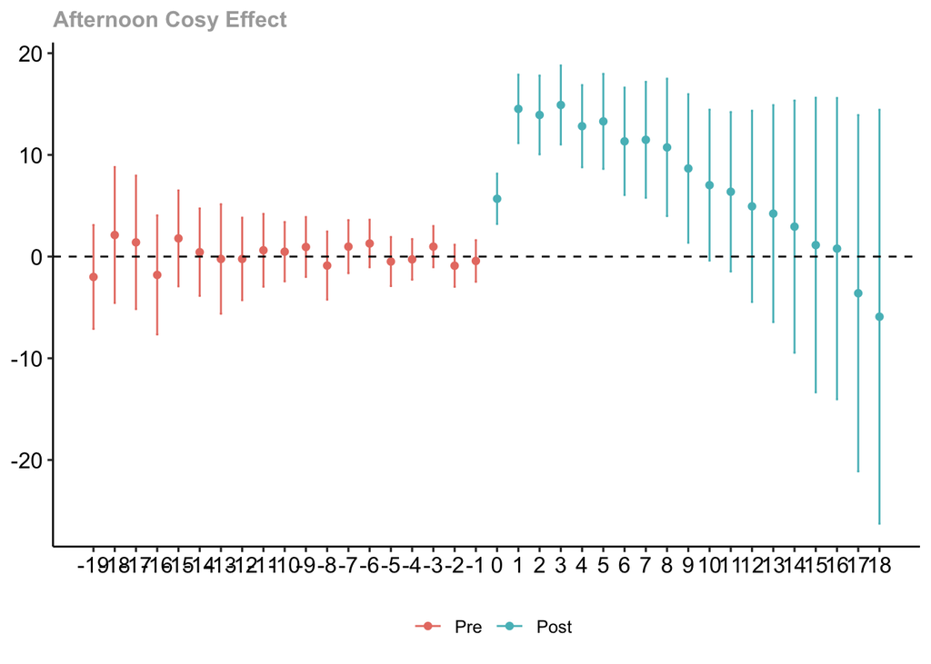

```
## [1] "Aggregate effect for Morning Cosy"
##
## Call:
## aggte(MP = est_cs, type = "simple", na.rm = TRUE, clustervars = "id")
##
## Reference: Callaway, Brantly and Pedro H.C. Sant'Anna.  "Difference-in-Differences with Multiple Time Periods." Journal of Econometrics, Vol. 225, No. 2, pp. 200-230, 2021. <https://doi.org/10.1016/j.jeconom.2020.12.001>, <https://arxiv.org/abs/1803.09015>
##
##
##      ATT    Std. Error     [ 95%  Conf. Int.]
##  16.2063        1.9153    12.4524     19.9602 *
##
##
## ---
## Signif. codes: `*' confidence band does not cover 0
##
## Control Group:  Not Yet Treated,  Anticipation Periods:  0
## Estimation Method:  Doubly Robust
## NULL
```

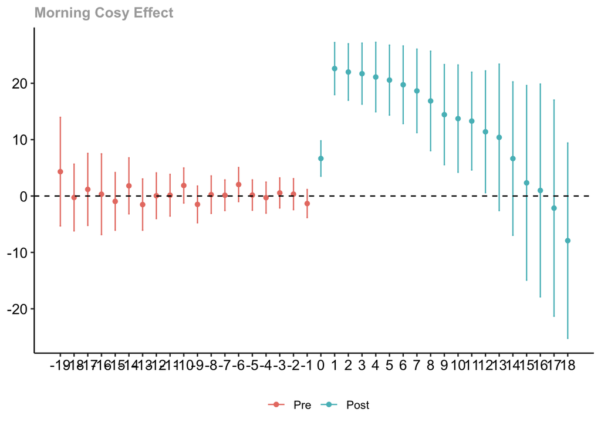

```
## [1] "Aggregate effect for Other"
##
## Call:
## aggte(MP = est_cs, type = "simple", na.rm = TRUE, clustervars = "id")
##
## Reference: Callaway, Brantly and Pedro H.C. Sant'Anna.  "Difference-in-Differences with Multiple Time Periods." Journal of Econometrics, Vol. 225, No. 2, pp. 200-230, 2021. <https://doi.org/10.1016/j.jeconom.2020.12.001>, <https://arxiv.org/abs/1803.09015>
##
##
##     ATT    Std. Error     [ 95%  Conf. Int.]
##  3.7872         7.676   -11.2575     18.8318
##
##
## ---
## Signif. codes: `*' confidence band does not cover 0
##
## Control Group:  Not Yet Treated,  Anticipation Periods:  0
## Estimation Method:  Doubly Robust
## NULL
```

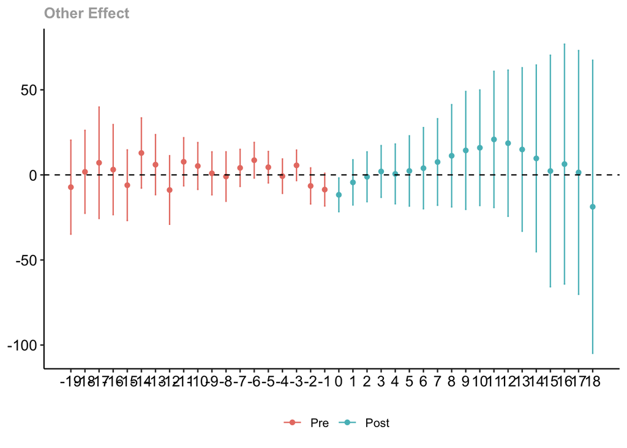

```
## [1] "Aggregate effect for Peak Rate"
##
## Call:
## aggte(MP = est_cs, type = "simple", na.rm = TRUE, clustervars = "id")
##
## Reference: Callaway, Brantly and Pedro H.C. Sant'Anna.  "Difference-in-Differences with Multiple Time Periods." Journal of Econometrics, Vol. 225, No. 2, pp. 200-230, 2021. <https://doi.org/10.1016/j.jeconom.2020.12.001>, <https://arxiv.org/abs/1803.09015>
##
##
##      ATT    Std. Error     [ 95%  Conf. Int.]
##  -5.0045        1.8932    -8.7151     -1.2939 *
##
##
## ---
## Signif. codes: `*' confidence band does not cover 0
##
## Control Group:  Not Yet Treated,  Anticipation Periods:  0
## Estimation Method:  Doubly Robust
## NULL
```

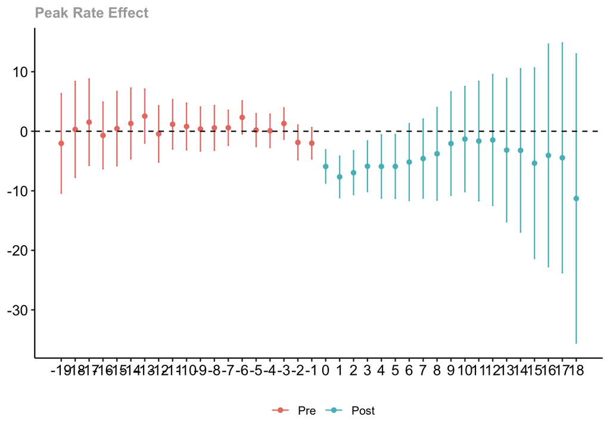

```r
# Getting unique rate periods to loop over
unique_periods <- unique(aggregated_data$rate_period)

if (!file.exists("data/scratch/estimates_list.RDS")) {

  # Initialize a list to store estimates for each period
  estimates_list <- list()

  for(period in unique_periods) {
    did_data <- aggregated_data %>%
      filter(rate_period == period) %>%
      mutate(week_cosy = as.numeric(ifelse(is_on_cosy == 1, week(date), NA))) %>%
      filter(!is.na(week_cosy)) %>%
      group_by(mpan, rate_period) %>%
      summarise(firstweek = min(week_cosy, na.rm = TRUE)) %>%
      inner_join(aggregated_data, by = c("mpan", "rate_period")) %>%
      mutate(week = week(date)) %>%
      group_by(mpan, firstweek, week, tariff_gsp_group_id) %>%
      summarise(total_consumption = sum(total_consumption),
                weekly_avg_cloud_cover_total = mean(daily_avg_cloud_cover_total),
                weekly_avg_heating_degree = mean(daily_avg_heating_degree),
                weekly_avg_wind_speed = mean(daily_avg_wind_speed)
      ) %>%
      mutate(id = as.numeric(mpan),
             week = as.numeric(week))

    # Estimating the treatment effect using the Callaway and Sant'Anna method
    est_cs <- att_gt(yname = "total_consumption",
                     tname = "week",
                     idname = "id",
                     gname = "firstweek",
                     data = did_data,
                     control_group="notyettreated",
                     allow_unbalanced_panel = TRUE)

    # agg
    agg.simple <- aggte(est_cs, type = "simple", na.rm = TRUE, clustervars="id")
    print(paste("Aggregate effect for", period))
    print(summary(agg.simple))

    # event study style
    agg.es <- aggte(est_cs, type = "dynamic", na.rm = TRUE, clustervars="id")

    # Store estimates in the list with period as the name
    estimates_list[[period]] <- list(simple = agg.simple, dynamic = agg.es)

    saveRDS(estimates_list, "data/scratch/estimates_list.RDS")
  }
} else {
  estimates_list <- readRDS("data/scratch/estimates_list.RDS")
}

for(period in unique_periods) {

  print(paste("Aggregate effect for", period))
  print(summary(estimates_list[[period]]$simple))

  # Plotting for each period
  ggdid_title <- paste(period, "Effect")
  print(ggdid(estimates_list[[period]]$dynamic, title = ggdid_title))

}
```